# Condition model

Max Lindmark & Sean Andersson

05 January, 2021

## Aim

Implement regularization using Gaussian priors with mean 0 different standard deviations, and compare the MSE on withheld and training data.

## Fit models

### Read data and set up spde mesh

```r
library(tidyverse); theme_set(theme_classic())
library(tidylog)
library(viridis)
library(sdmTMB) # remotes::install_github("pbs-assess/sdmTMB")
library(marmap)
library(rnaturalearth)
library(rnaturalearthdata)
library(sf)
library(RColorBrewer)
library(gganimate)
library(gifski)
library(latex2exp)
library(patchwork)
library(png)
library(qwraps2) # To load entire cache in interactive r session, do: qwraps2::lazyload_cache_dir(path = "R/analysis/condition_model_cache/html")

# For adding maps to plots
world <- ne_countries(scale = "medium", returnclass = "sf")

# Specify map ranges
ymin = 54; ymax = 58; xmin = 9.5; xmax = 22
```

Now read data:

```r
d <- readr::read_csv("https://raw.githubusercontent.com/maxlindmark/cod_condition/master/data/for_analysis/mdat_cond.csv")

# Calculate standardized variables
# Calculate standardized variables
d <- d %>%
  mutate(ln_length_cm = log(length_cm),
         ln_weight_g = log(weight_g),
         oxy_st = oxy,
         oxy_rec_st = oxy_rec,
         temp_st = temp,
         temp_rec_st = temp_rec,
         abun_her_st = abun_her,
         abun_her_sd_st = abun_her_sd,
         abun_spr_st = abun_spr,
         abun_spr_sd_st = abun_spr_sd,
         cpue_cod_st = cpue_cod,
         cpue_cod_rec_st = cpue_cod_rec,
         cpue_fle_st = cpue_fle,
         cpue_fle_rec_st = cpue_fle_rec,
         depth_st = depth) %>%
  mutate_at(c("oxy_st", "oxy_rec_st", "temp_st", "temp_rec_st",
              "abun_her_st", "abun_her_sd_st", "abun_spr_st", "abun_spr_sd_st",
              "cpue_cod_st", "cpue_cod_rec_st", "cpue_fle_st", "cpue_fle_rec_st",
              "depth_st"),
            ~(scale(.) %>% as.vector)) %>%
  mutate(year = as.integer(year))
```

Read the prediction grids:

```r
pred_grid <- readr::read_csv("https://raw.githubusercontent.com/maxlindmark/cod_condition/master/data/for_analysis/pred_grid.csv")

pred_grid <- pred_grid %>%
  mutate(ln_length_cm = log(1)) %>% # For now we'll predict changes in the intercept ("condition factor")
  mutate(X = lon,
         Y = lat,
         year = as.integer(year),
         depth_st = 0) %>% # In this prediction grid I keep depth at its mean, below I have a more realistic prediction grid
  filter(year %in% c(unique(d$year)))

# And now read in pred_grid2 which has oxygen values at location and time and depth:
pred_grid2 <- readr::read_csv("https://raw.githubusercontent.com/maxlindmark/cod_condition/master/data/for_analysis/pred_grid2.csv")

pred_grid2 <- pred_grid2 %>%
  mutate(ln_length_cm = log(1)) %>% # For now we'll predict changes in the intercept ("condition factor")
  mutate(X = lon, Y = lat, year = as.integer(year)) %>%
  filter(year %in% c(unique(d$year))) %>%
  mutate(depth_st = (depth - mean(d$depth))/sd(d$depth),
         temp_st = (temp - mean(d$temp))/sd(d$temp),
         oxy_st = (oxy - mean(d$oxy))/sd(d$oxy)) # Need to scale these to the mean and sd in the data!
```

In earlier versions we used this: `spde <- make_mesh(data = d, xy_cols = c("lon", "lat"), n_knots = 110, type = "kmeans", seed = 42)`. But now we have even more islands in the data since I am using also the western Baltic Sea, so we will use the `add_barrier_mesh` to include an island effect (following the example function). Note this also means we can increase the # of knots before hitting convergence issues (how much varies from model to model though!)

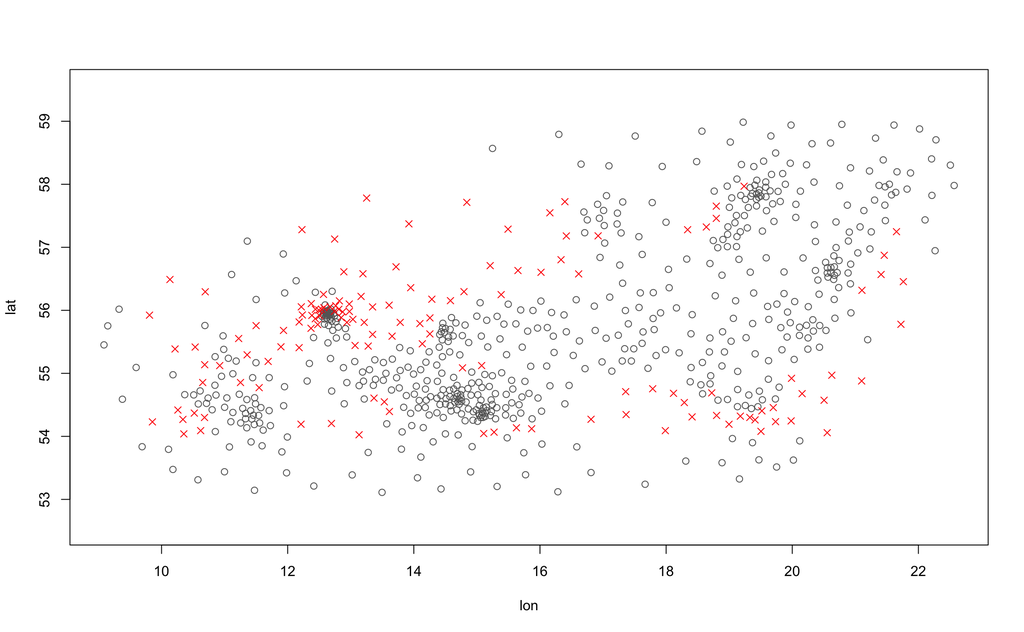

```r
# Crop the polygon for plotting and efficiency:
baltic_coast <- suppressWarnings(suppressMessages(
  st_crop(world,
          c(xmin = xmin, ymin = ymin, xmax = xmax, ymax = ymax))))

crs <- 4326 # https://en.wikipedia.org/wiki/EPSG_Geodetic_Parameter_Dataset#Common_EPSG_codes, WGS84

st_crs(baltic_coast) <- 4326 # 'WGS84'; necessary on some installs
baltic_coast <- st_transform(baltic_coast, crs)

# Project our survey data coordinates:
survey <- d %>% dplyr::select(lon, lat, ln_weight_g) %>%
  st_as_sf(crs = 4326, coords = c("lon", "lat"))

# Prepare for making the mesh
# First, we will extract the coordinates:
surv_coords <- st_coordinates(survey)

spde <- make_mesh(d, xy_cols = c("lon", "lat"),
                  n_knots = 160, # 180 works nice as well but 160 works with the 80% training data
                  type = "kmeans", seed = 42)

# Add on the barrier mesh component:
bspde <- add_barrier_mesh(
  spde, baltic_coast, range_fraction = 0.2,
  proj_scaling = 1, plot = TRUE
)
```

```r
# In the above, the grey dots are the centre of triangles that are in the
# ocean. The red crosses are centres of triangles that are over land. The
# spatial range will be assumed to be 0.2 (`range_fraction`) over land compared
# to over water.

# We can make a more advanced plot if we want:
mesh_df_water <- bspde$mesh_sf[bspde$normal_triangles, ]
mesh_df_land <- bspde$mesh_sf[bspde$barrier_triangles, ]

# Now, when we fit our model with the new mesh, it will automatically
# include a barrier structure in the spatial correlation:
```

### Default model (no additional covariates)

```r
mdef <- sdmTMB(formula = ln_weight_g ~ ln_length_cm + depth_st -1, time_varying = ~ 1, data = d, time = "year",
                spde = bspde, family = student(link = "identity", df = 5), ar1_fields = TRUE,
                include_spatial = TRUE, spatial_trend = FALSE, spatial_only = FALSE,
                silent = TRUE, newton_steps = 1, reml = FALSE)

tidy(mdef, conf.int = TRUE)
```

| term | estimate | std.error | conf.low | conf.high |
| --- | --- | --- | --- | --- |
| ln_length_cm | 2.97879846 | 0.0008906146 | 2.97705288 | 2.98054403 |
| depth_st | -0.02865696 | 0.0014873390 | -0.03157209 | -0.02574183 |

### Full model

```r
mfull <- sdmTMB(formula = ln_weight_g ~ ln_length_cm + depth_st + oxy_st + oxy_rec_st + cpue_fle_st + cpue_fle_rec_st + cpue_cod_st + cpue_cod_rec_st + abun_spr_st + abun_spr_sd_st + abun_her_st + abun_her_sd_st + oxy_st*depth_st + temp_st*depth_st -1, time_varying = ~ 1, data = d, time = "year",
                spde = bspde, family = student(link = "identity", df = 5), ar1_fields = TRUE,
                include_spatial = TRUE, spatial_trend = FALSE, spatial_only = FALSE,
                silent = TRUE, newton_steps = 1, reml = FALSE)

tidy(mfull, conf.int = TRUE)
```

| term | estimate | std.error | conf.low | conf.high |
| --- | --- | --- | --- | --- |
| ln_length_cm | 2.982857e+00 | 0.0008943148 | 2.9811043174 | 2.9846099668 |
| depth_st | -1.930877e-02 | 0.0006839375 | -0.0206492658 | -0.0179682799 |
| oxy_st | 1.253094e-02 | 0.0008225916 | 0.0109186891 | 0.0141431888 |
| oxy_rec_st | 5.321253e-03 | 0.0007279130 | 0.0038945693 | 0.0067479357 |
| cpue_fle_st | 6.040118e-04 | 0.0008027906 | -0.0009694289 | 0.0021774524 |
| cpue_fle_rec_st | -1.851014e-04 | 0.0008527849 | -0.0018565291 | 0.0014863264 |
| cpue_cod_st | -1.441727e-04 | 0.0004817107 | -0.0010883083 | 0.0007999629 |
| cpue_cod_rec_st | 2.971031e-04 | 0.0004905022 | -0.0006642636 | 0.0012584698 |
| abun_spr_st | 2.373935e-03 | 0.0005563296 | 0.0012835492 | 0.0034643213 |
| abun_spr_sd_st | 1.108331e-02 | 0.0006820178 | 0.0097465769 | 0.0124200376 |

[output cut: 5 more lines]

### Full model with regularization

```r
# Create a vector with standard deviations for the normal distribution (mean 0) that is the prior for the fixed effect. The penalties vector should correspond to the columns of the X_ij matrix.
penalty_vec <- rep(1, length(colnames(mfull$tmb_data$X_ij)))

# Remove penalty for the length-coefficient
penalty_vec[1] <- NA

mreg <- sdmTMB(formula = ln_weight_g ~ ln_length_cm + depth_st + oxy_st + oxy_rec_st + cpue_fle_st + cpue_fle_rec_st + cpue_cod_st + cpue_cod_rec_st + abun_spr_st + abun_spr_sd_st + abun_her_st + abun_her_sd_st + oxy_st*depth_st + temp_st*depth_st -1, time_varying = ~ 1, data = d, time = "year",
               spde = bspde, family = student(link = "identity", df = 5), ar1_fields = TRUE,
               include_spatial = TRUE, spatial_trend = FALSE, spatial_only = FALSE,
               silent = TRUE, newton_steps = 1, reml = FALSE,
               penalties = penalty_vec)

tidy(mreg, conf.int = TRUE)
```

| term | estimate | std.error | conf.low | conf.high |
| --- | --- | --- | --- | --- |
| ln_length_cm | 2.982857e+00 | 0.0008943147 | 2.9811043168 | 2.9846099661 |
| depth_st | -1.930877e-02 | 0.0006839373 | -0.0206492613 | -0.0179682765 |
| oxy_st | 1.253094e-02 | 0.0008225911 | 0.0109186866 | 0.0141431846 |
| oxy_rec_st | 5.321254e-03 | 0.0007279126 | 0.0038945719 | 0.0067479370 |
| cpue_fle_st | 6.040127e-04 | 0.0008027901 | -0.0009694270 | 0.0021774525 |
| cpue_fle_rec_st | -1.851002e-04 | 0.0008527844 | -0.0018565270 | 0.0014863266 |
| cpue_cod_st | -1.441744e-04 | 0.0004817106 | -0.0010883098 | 0.0007999611 |
| cpue_cod_rec_st | 2.971029e-04 | 0.0004905021 | -0.0006642637 | 0.0012584694 |
| abun_spr_st | 2.373936e-03 | 0.0005563295 | 0.0012835504 | 0.0034643220 |
| abun_spr_sd_st | 1.108330e-02 | 0.0006820176 | 0.0097465700 | 0.0124200299 |

[output cut: 5 more lines]

### Full model with regularization (sd = 0.1)

```r
# Create a vector with standard deviations for the normal distribution (mean 0) that is the prior for the fixed effect. The penalties vector should correspond to the columns of the X_ij matrix.
penalty_vec2 <- rep(0.1, length(colnames(mfull$tmb_data$X_ij)))

# Remove penalty for the length-coefficient
penalty_vec2[1] <- NA

mreg2 <- sdmTMB(formula = ln_weight_g ~ ln_length_cm + depth_st + oxy_st + oxy_rec_st + cpue_fle_st + cpue_fle_rec_st + cpue_cod_st + cpue_cod_rec_st + abun_spr_st + abun_spr_sd_st + abun_her_st + abun_her_sd_st + oxy_st*depth_st + temp_st*depth_st -1, time_varying = ~ 1, data = d, time = "year",
               spde = bspde, family = student(link = "identity", df = 5), ar1_fields = TRUE,
               include_spatial = TRUE, spatial_trend = FALSE, spatial_only = FALSE,
               silent = TRUE, newton_steps = 1, reml = FALSE,
               penalties = penalty_vec2)

tidy(mreg2, conf.int = TRUE)
```

| term | estimate | std.error | conf.low | conf.high |
| --- | --- | --- | --- | --- |
| ln_length_cm | 2.9828570739 | 0.0008943146 | 2.9811042496 | 2.9846098983 |
| depth_st | -0.0193083870 | 0.0006839111 | -0.0206488281 | -0.0179679458 |
| oxy_st | 0.0125305922 | 0.0008225462 | 0.0109184312 | 0.0141427532 |
| oxy_rec_st | 0.0053214542 | 0.0007278826 | 0.0038948306 | 0.0067480778 |
| cpue_fle_st | 0.0006040822 | 0.0008027445 | -0.0009692681 | 0.0021774325 |
| cpue_fle_rec_st | -0.0001849690 | 0.0008527341 | -0.0018562971 | 0.0014863592 |
| cpue_cod_st | -0.0001441710 | 0.0004817033 | -0.0010882922 | 0.0007999502 |
| cpue_cod_rec_st | 0.0002970037 | 0.0004904945 | -0.0006643479 | 0.0012583553 |
| abun_spr_st | 0.0023740377 | 0.0005563181 | 0.0012836742 | 0.0034644013 |
| abun_spr_sd_st | 0.0110825853 | 0.0006819980 | 0.0097458939 | 0.0124192768 |

[output cut: 5 more lines]

### Full model with regularization (sd = 0.01)

```r
# Create a vector with standard deviations for the normal distribution (mean 0) that is the prior for the fixed effect. The penalties vector should correspond to the columns of the X_ij matrix.
penalty_vec3 <- rep(0.01, length(colnames(mfull$tmb_data$X_ij)))

# Remove penalty for the length-coefficient
penalty_vec3[1] <- NA

mreg3 <- sdmTMB(formula = ln_weight_g ~ ln_length_cm + depth_st + oxy_st + oxy_rec_st + cpue_fle_st + cpue_fle_rec_st + cpue_cod_st + cpue_cod_rec_st + abun_spr_st + abun_spr_sd_st + abun_her_st + abun_her_sd_st + oxy_st*depth_st + temp_st*depth_st -1, time_varying = ~ 1, data = d, time = "year",
               spde = bspde, family = student(link = "identity", df = 5), ar1_fields = TRUE,
               include_spatial = TRUE, spatial_trend = FALSE, spatial_only = FALSE,
               silent = TRUE, newton_steps = 1, reml = FALSE,
               penalties = penalty_vec3)

tidy(mreg3, conf.int = TRUE)
```

| term | estimate | std.error | conf.low | conf.high |
| --- | --- | --- | --- | --- |
| ln_length_cm | 2.982850e+00 | 0.0008942964 | 2.9810975416 | 2.9846031190 |
| depth_st | -1.927025e-02 | 0.0006813130 | -0.0206055967 | -0.0179348988 |
| oxy_st | 1.249655e-02 | 0.0008180980 | 0.0108931036 | 0.0140999889 |
| oxy_rec_st | 5.341205e-03 | 0.0007248962 | 0.0039204350 | 0.0067619760 |
| cpue_fle_st | 6.109895e-04 | 0.0007982257 | -0.0009535041 | 0.0021754830 |
| cpue_fle_rec_st | -1.719211e-04 | 0.0008477538 | -0.0018334880 | 0.0014896458 |
| cpue_cod_st | -1.438413e-04 | 0.0004809782 | -0.0010865413 | 0.0007988586 |
| cpue_cod_rec_st | 2.871524e-04 | 0.0004897348 | -0.0006727101 | 0.0012470149 |
| abun_spr_st | 2.384037e-03 | 0.0005551864 | 0.0012958917 | 0.0034721823 |
| abun_spr_sd_st | 1.101155e-02 | 0.0006800423 | 0.0096786882 | 0.0123444049 |

[output cut: 5 more lines]

### Full model with regularization (sd = 0.001)

```r
# Create a vector with standard deviations for the normal distribution (mean 0) that is the prior for the fixed effect. The penalties vector should correspond to the columns of the X_ij matrix.
penalty_vec4 <- rep(0.001, length(colnames(mfull$tmb_data$X_ij)))

# Remove penalty for the length-coefficient
penalty_vec4[1] <- NA

mreg4 <- sdmTMB(formula = ln_weight_g ~ ln_length_cm + depth_st + oxy_st + oxy_rec_st + cpue_fle_st + cpue_fle_rec_st + cpue_cod_st + cpue_cod_rec_st + abun_spr_st + abun_spr_sd_st + abun_her_st + abun_her_sd_st + oxy_st*depth_st + temp_st*depth_st -1, time_varying = ~ 1, data = d, time = "year",
               spde = bspde, family = student(link = "identity", df = 5), ar1_fields = TRUE,
               include_spatial = TRUE, spatial_trend = FALSE, spatial_only = FALSE,
               silent = TRUE, newton_steps = 1, reml = FALSE,
               penalties = penalty_vec4)

tidy(mreg4, conf.int = TRUE)
```

| term | estimate | std.error | conf.low | conf.high |
| --- | --- | --- | --- | --- |
| ln_length_cm | 2.9822529028 | 0.0008934981 | 2.980502e+00 | 2.9840041269 |
| depth_st | -0.0161425409 | 0.0005259199 | -1.717332e-02 | -0.0151117569 |
| oxy_st | 0.0104806442 | 0.0005775962 | 9.348576e-03 | 0.0116127119 |
| oxy_rec_st | 0.0061617415 | 0.0005486576 | 5.086392e-03 | 0.0072370906 |
| cpue_fle_st | 0.0010859828 | 0.0005612008 | -1.395065e-05 | 0.0021859163 |
| cpue_fle_rec_st | 0.0006152647 | 0.0005870465 | -5.353253e-04 | 0.0017658547 |
| cpue_cod_st | -0.0001687612 | 0.0004238940 | -9.995781e-04 | 0.0006620558 |
| cpue_cod_rec_st | -0.0002807947 | 0.0004301268 | -1.123828e-03 | 0.0005622382 |
| abun_spr_st | 0.0025885627 | 0.0004726791 | 1.662129e-03 | 0.0035149967 |
| abun_spr_sd_st | 0.0065604824 | 0.0005456949 | 5.490940e-03 | 0.0076300249 |

[output cut: 5 more lines]

## Compare estimates across models

```r
est <- bind_rows(tidy(mfull, conf.int = TRUE) %>% mutate(model = "full no prior"),
                 tidy(mreg, conf.int = TRUE) %>% mutate(model = "sd=1"),
                 tidy(mreg2, conf.int = TRUE) %>% mutate(model = "sd=0.1"),
                 tidy(mreg3, conf.int = TRUE) %>% mutate(model = "sd=0.01"),
                 tidy(mreg4, conf.int = TRUE) %>% mutate(model = "sd=0.001"))
```

```
#> mutate: new variable 'model' (character) with one unique value and 0% NA
#> mutate: new variable 'model' (character) with one unique value and 0% NA
#> mutate: new variable 'model' (character) with one unique value and 0% NA
#> mutate: new variable 'model' (character) with one unique value and 0% NA
#> mutate: new variable 'model' (character) with one unique value and 0% NA
```

```
#> filter: removed one row (7%), 14 rows remaining
```

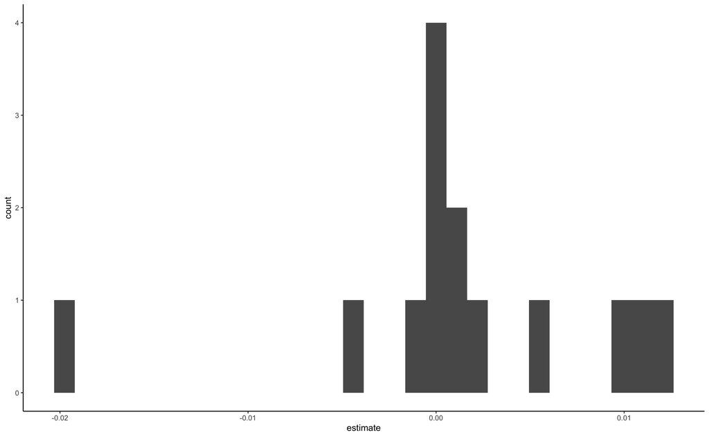

```r
dodge <- position_dodge(width = 0.5)

mfull %>%
  tidy(conf.int = TRUE) %>%
  filter(!term == "ln_length_cm") %>%
  ggplot(., aes(estimate)) + geom_histogram()
```

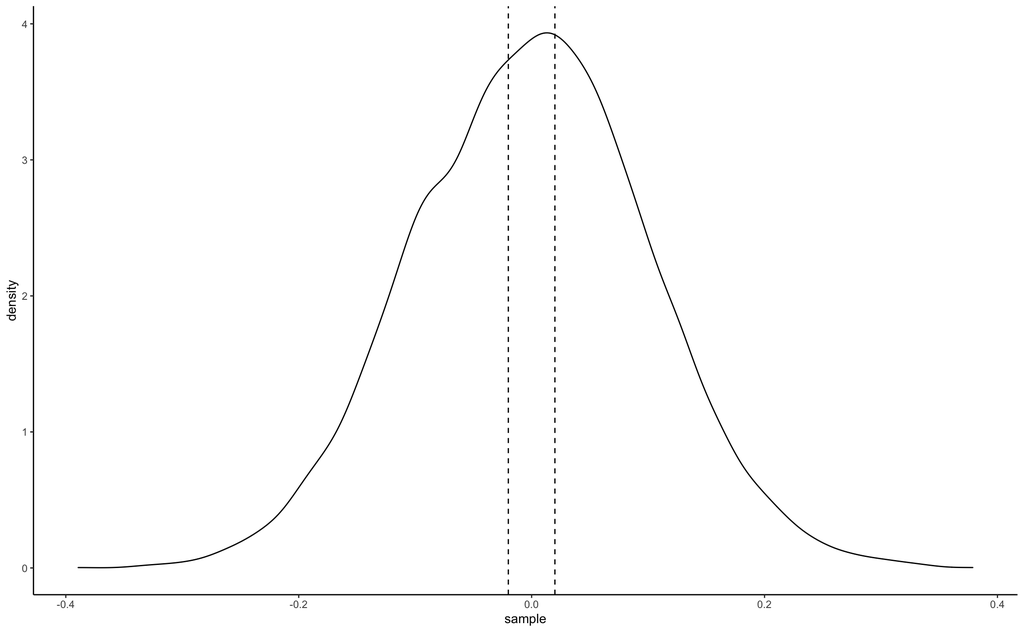

```r
x <- data.frame(sample = rnorm(10000, 0, 0.1))

ggplot(x, aes(sample)) +
  geom_density() +
  geom_vline(xintercept = c(-0.02, 0.02), linetype = 2)
```

```
#> filter: removed one row (7%), 14 rows remaining
```

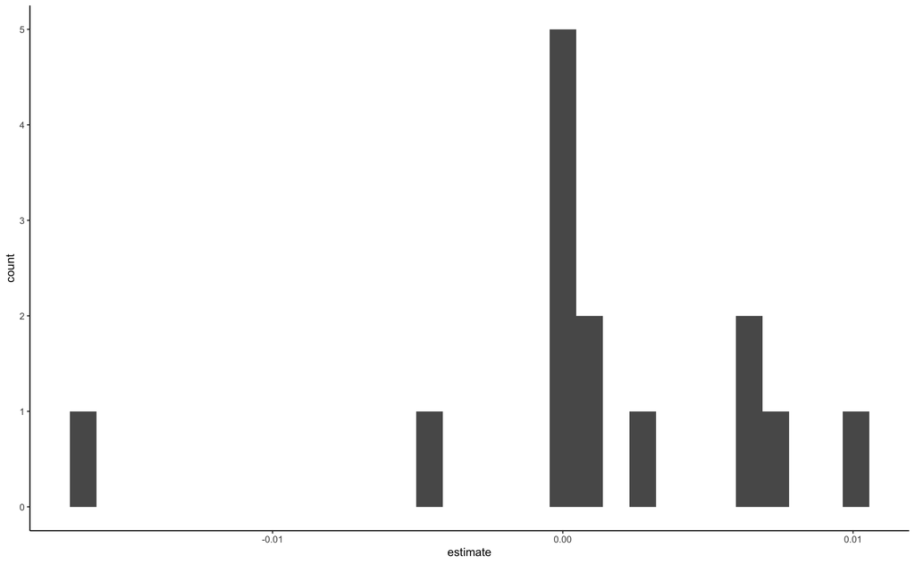

```r
mreg4 %>%
  tidy(conf.int = TRUE) %>%
  filter(!term == "ln_length_cm") %>%
  ggplot(., aes(estimate)) + geom_histogram()
```

```r
# Check the length-exponent real quick
est %>% filter(term == "ln_length_cm")
```

```
#> filter: removed 70 rows (93%), 5 rows remaining
```

| term | estimate | std.error | conf.low | conf.high | model |
| --- | --- | --- | --- | --- | --- |
| ln_length_cm | 2.982857 | 0.0008943148 | 2.981104 | 2.984610 | full no prior |
| ln_length_cm | 2.982857 | 0.0008943147 | 2.981104 | 2.984610 | sd=1 |
| ln_length_cm | 2.982857 | 0.0008943146 | 2.981104 | 2.984610 | sd=0.1 |
| ln_length_cm | 2.982850 | 0.0008942964 | 2.981098 | 2.984603 | sd=0.01 |
| ln_length_cm | 2.982253 | 0.0008934981 | 2.980502 | 2.984004 | sd=0.001 |

```
#> filter: removed 5 rows (7%), 70 rows remaining
```

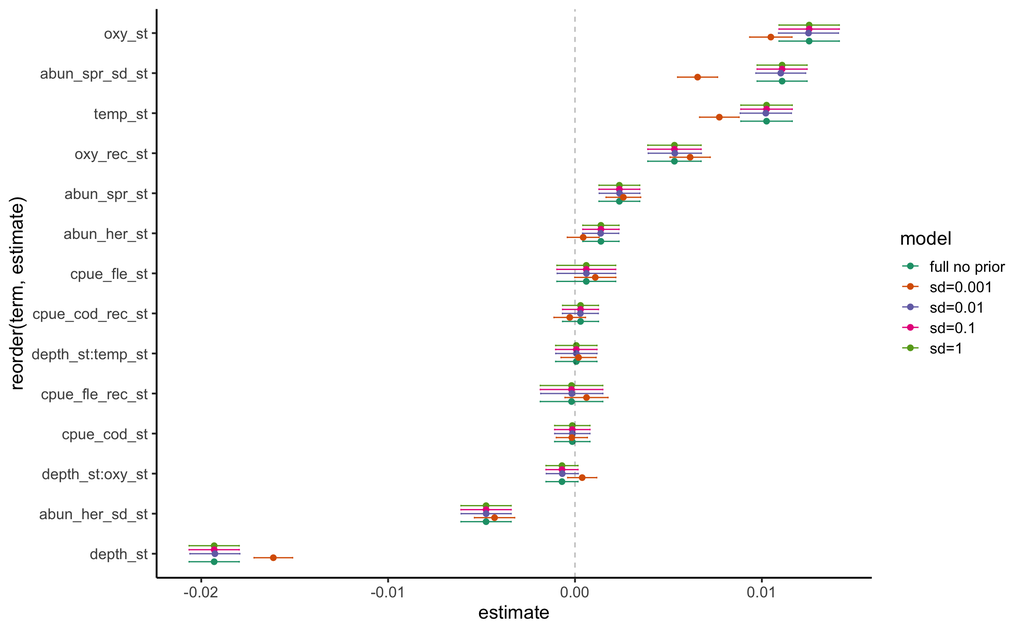

```r
est %>%
  filter(!term == "ln_length_cm") %>%
  ggplot(., aes(reorder(term, estimate), estimate, color = model)) +
  geom_point(size = 2, position = dodge) +
  geom_hline(yintercept = 0, linetype = 2, alpha = 0.3) +
  geom_errorbar(aes(ymin = conf.low, ymax = conf.high), width = 0.2, position = dodge) +
  coord_flip() +
  scale_color_brewer(palette = "Dark2") +
  theme_classic(base_size = 16)
```

```r
  NULL
```

The difference in parameter estimates are very small when I include a prior, unless the sd is tight. See if the full model is overfit. If it has a tendency to overfitting compared to the default model, do regularization. Does the sd=1 regularization affect overfitting? If no, try smaller sds. How small? Determine which sd gives the best cross val error.

### Evalute out-of-sample predictive accuracy

```r
# Remove NA data (some rectangles don't have data for all years)
d <- d %>% drop_na(abun_spr_st)
```

```
#> drop_na: removed 2,849 rows (3%), 100,205 rows remaining
```

```r
# First take a random subset (80% of data) for training the model
train_size <- 0.8*nrow(d)
set.seed(42)
train_rows <- sample.int(nrow(d), train_size)
train <- d[train_rows, ]

# Assign rows as either for training or for later prediction (withheld)
d <- d %>%
  mutate(row_n = 1:n(),
         split = ifelse(row_n %in% train_rows, "train", "withheld"))
```

```
#> mutate: new variable 'row_n' (integer) with 100,205 unique values and 0% NA
#>         new variable 'split' (character) with 2 unique values and 0% NA
```

```
#> group_by: 2 grouping variables (year, split)
#> summarize: now 52 rows and 3 columns, one group variable remaining (year)
```

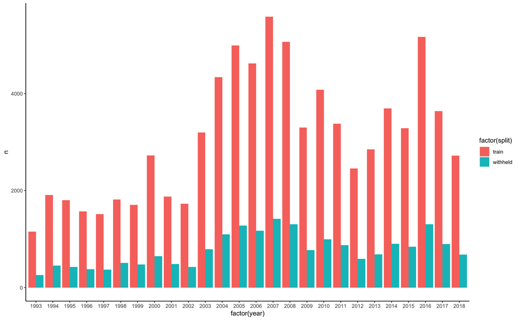

```r
# Plot just to see
d %>% group_by(year, split) %>% summarize(n = n()) %>%
  ggplot(., aes(factor(year), n, fill = factor(split))) +
  geom_bar(stat = "identity", position = "dodge")
```

```r
# Now I think we need to redo the spde mesh, because we now fit the model using only 80 % of the data
# Project our survey data coordinates:
survey_train <- filter(d, split == "train") %>% dplyr::select(lon, lat, ln_weight_g) %>%
  st_as_sf(crs = 4326, coords = c("lon", "lat"))
```

```
#> filter: removed 20,041 rows (20%), 80,164 rows remaining
```

```r
# Prepare for making the mesh
# First, we will extract the coordinates:
surv_coords <- st_coordinates(survey_train)

spde_train <- make_mesh(filter(d, split == "train"), xy_cols = c("lon", "lat"),
                        n_knots = 160,
                        type = "kmeans", seed = 42)
```

```
#> filter: removed 20,041 rows (20%), 80,164 rows remaining
```

```
#> although coordinates are longitude/latitude, st_intersects assumes that they are planar
#> although coordinates are longitude/latitude, st_intersects assumes that they are planar
```

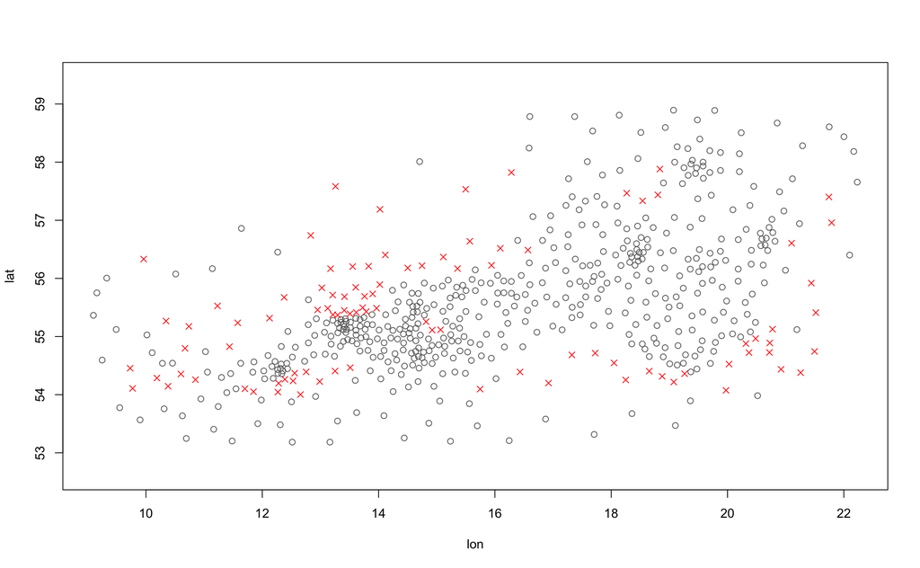

```r
# Add on the barrier mesh component:
bspde_train <- add_barrier_mesh(
  spde_train, baltic_coast, range_fraction = 0.2,
  proj_scaling = 1, plot = TRUE
)
```

```r
# Now we need to extract the residuals from the predictions on the training data and the withheld data
# First, borrow some functions from sdmTMB to calculate quantile residuals: https://github.com/pbs-assess/sdmTMB/blob/master/R/residuals.R
pt_ls <- function(q, df, mu, sigma) stats::pt((q - mu)/sigma, df)

qres_student <- function(object, y, mu) {
  dispersion <- exp(object$model$par[["ln_phi"]])
  u <- pt_ls(q = y, df = object$tmb_data$df, mu = mu, sigma = dispersion)
  stats::qnorm(u)
}
```

Now fit the models on the training data.

```r
# No penalty
mnp <- sdmTMB(formula = ln_weight_g ~ ln_length_cm + depth_st + oxy_st + oxy_rec_st + cpue_fle_st + cpue_fle_rec_st + cpue_cod_st + cpue_cod_rec_st + abun_spr_st + abun_spr_sd_st + abun_her_st + abun_her_sd_st + oxy_st*depth_st + temp_st*depth_st -1, time_varying = ~ 1,
              data = filter(d, split == "train"),
              time = "year", spde = bspde_train, family = student(link = "identity", df = 5),
              ar1_fields = TRUE, include_spatial = TRUE, spatial_trend = FALSE,
              spatial_only = FALSE, silent = TRUE, newton_steps = 1, reml = FALSE)
```

```
#> filter: removed 20,041 rows (20%), 80,164 rows remaining
#> Warning: The model may not have converged. Maximum final gradient:
#> 0.0275857434704925.
```

```r
# sd = 1
m1 <- sdmTMB(formula = ln_weight_g ~ ln_length_cm + depth_st + oxy_st + oxy_rec_st + cpue_fle_st + cpue_fle_rec_st + cpue_cod_st + cpue_cod_rec_st + abun_spr_st + abun_spr_sd_st + abun_her_st + abun_her_sd_st + oxy_st*depth_st + temp_st*depth_st -1, time_varying = ~ 1,
             data = filter(d, split == "train"),
             time = "year", spde = bspde_train, family = student(link = "identity", df = 5),
             ar1_fields = TRUE, include_spatial = TRUE, spatial_trend = FALSE,
             spatial_only = FALSE, silent = TRUE, newton_steps = 1, reml = FALSE,
             penalties = penalty_vec)
```

```
#> filter: removed 20,041 rows (20%), 80,164 rows remaining
```

```r
# sd = 0.1
m01 <- sdmTMB(formula = ln_weight_g ~ ln_length_cm + depth_st + oxy_st + oxy_rec_st + cpue_fle_st + cpue_fle_rec_st + cpue_cod_st + cpue_cod_rec_st + abun_spr_st + abun_spr_sd_st + abun_her_st + abun_her_sd_st + oxy_st*depth_st + temp_st*depth_st -1, time_varying = ~ 1,
              data = filter(d, split == "train"),
              time = "year", spde = bspde_train, family = student(link = "identity", df = 5),
              ar1_fields = TRUE, include_spatial = TRUE, spatial_trend = FALSE,
              spatial_only = FALSE, silent = TRUE, newton_steps = 1, reml = FALSE,
              penalties = penalty_vec2)
```

```
#> filter: removed 20,041 rows (20%), 80,164 rows remaining
```

```r
# sd = 0.01
m001 <- sdmTMB(formula = ln_weight_g ~ ln_length_cm + depth_st + oxy_st + oxy_rec_st + cpue_fle_st + cpue_fle_rec_st + cpue_cod_st + cpue_cod_rec_st + abun_spr_st + abun_spr_sd_st + abun_her_st + abun_her_sd_st + oxy_st*depth_st + temp_st*depth_st -1, time_varying = ~ 1,
               data = filter(d, split == "train"),
               time = "year", spde = bspde_train, family = student(link = "identity", df = 5),
               ar1_fields = TRUE, include_spatial = TRUE, spatial_trend = FALSE,
               spatial_only = FALSE, silent = TRUE, newton_steps = 1, reml = FALSE,
               penalties = penalty_vec3)
```

```
#> filter: removed 20,041 rows (20%), 80,164 rows remaining
```

```r
# sd = 0.001
m0001 <- sdmTMB(formula = ln_weight_g ~ ln_length_cm + depth_st + oxy_st + oxy_rec_st + cpue_fle_st + cpue_fle_rec_st + cpue_cod_st + cpue_cod_rec_st + abun_spr_st + abun_spr_sd_st + abun_her_st + abun_her_sd_st + oxy_st*depth_st + temp_st*depth_st -1, time_varying = ~ 1,
                data = filter(d, split == "train"),
                time = "year", spde = bspde_train, family = student(link = "identity", df = 5),
                ar1_fields = TRUE, include_spatial = TRUE, spatial_trend = FALSE,
                spatial_only = FALSE, silent = TRUE, newton_steps = 1, reml = FALSE,
                penalties = penalty_vec4)
```

```
#> filter: removed 20,041 rows (20%), 80,164 rows remaining
```

```r
# Also include the model without covariates just for comparison - no penalty
mdef2 <- sdmTMB(formula = ln_weight_g ~ ln_length_cm + depth_st -1, time_varying = ~ 1,
                data = filter(d, split == "train"),
                time = "year", spde = bspde_train, family = student(link = "identity", df = 5),
                ar1_fields = TRUE, include_spatial = TRUE, spatial_trend = FALSE,
                spatial_only = FALSE, silent = TRUE, newton_steps = 1, reml = FALSE)
```

```
#> filter: removed 20,041 rows (20%), 80,164 rows remaining
```

Calculate the models’ predictive error

```r
# no penalty
res_mnp_train <- qres_student(object = mnp,
                              y = filter(d, split == "train")$ln_weight_g,
                              mu = predict(mnp)$est)
```

```
#> filter: removed 20,041 rows (20%), 80,164 rows remaining
```

```r
res_mnp_withheld <- qres_student(object = mnp,
                                 y = filter(d, split == "withheld")$ln_weight_g,
                                 mu = predict(mnp, newdata = filter(d, split == "withheld"))$est)
```

```
#> filter: removed 80,164 rows (80%), 20,041 rows remaining
#> filter: removed 80,164 rows (80%), 20,041 rows remaining
```

```r
# sd = 1
res_m1_train <- qres_student(object = m1,
                             y = filter(d, split == "train")$ln_weight_g,
                             mu = predict(m1)$est)
```

```
#> filter: removed 20,041 rows (20%), 80,164 rows remaining
```

```r
res_m1_withheld <- qres_student(object = m1,
                                y = filter(d, split == "withheld")$ln_weight_g,
                                mu = predict(m1, newdata = filter(d, split == "withheld"))$est)
```

```
#> filter: removed 80,164 rows (80%), 20,041 rows remaining
#> filter: removed 80,164 rows (80%), 20,041 rows remaining
```

```r
# sd = 0.1
res_m01_train <- qres_student(object = m01,
                              y = filter(d, split == "train")$ln_weight_g,
                              mu = predict(m01)$est)
```

```
#> filter: removed 20,041 rows (20%), 80,164 rows remaining
```

```r
res_m01_withheld <- qres_student(object = m01,
                                 y = filter(d, split == "withheld")$ln_weight_g,
                                 mu = predict(m01, newdata = filter(d, split == "withheld"))$est)
```

```
#> filter: removed 80,164 rows (80%), 20,041 rows remaining
#> filter: removed 80,164 rows (80%), 20,041 rows remaining
```

```r
# sd = 0.01
res_m001_train <- qres_student(object = m001,
                               y = filter(d, split == "train")$ln_weight_g,
                               mu = predict(m001)$est)
```

```
#> filter: removed 20,041 rows (20%), 80,164 rows remaining
```

```r
res_m001_withheld <- qres_student(object = m001,
                                  y = filter(d, split == "withheld")$ln_weight_g,
                                  mu = predict(m001, newdata = filter(d, split == "withheld"))$est)
```

```
#> filter: removed 80,164 rows (80%), 20,041 rows remaining
#> filter: removed 80,164 rows (80%), 20,041 rows remaining
```

```r
# sd = 0.001
res_m0001_train <- qres_student(object = m0001,
                                y = filter(d, split == "train")$ln_weight_g,
                                mu = predict(m0001)$est)
```

```
#> filter: removed 20,041 rows (20%), 80,164 rows remaining
```

```r
res_m0001_withheld <- qres_student(object = m0001,
                                   y = filter(d, split == "withheld")$ln_weight_g,
                                   mu = predict(m0001, newdata = filter(d, split == "withheld"))$est)
```

```
#> filter: removed 80,164 rows (80%), 20,041 rows remaining
#> filter: removed 80,164 rows (80%), 20,041 rows remaining
```

```r
# default model, no penalties
res_mdef2_train <- qres_student(object = mdef2,
                                y = filter(d, split == "train")$ln_weight_g,
                                mu = predict(mdef2)$est)
```

```
#> filter: removed 20,041 rows (20%), 80,164 rows remaining
```

```r
res_mdef2_withheld <- qres_student(object = mdef2,
                                   y = filter(d, split == "withheld")$ln_weight_g,
                                   mu = predict(mdef2, newdata = filter(d, split == "withheld"))$est)
```

```
#> filter: removed 80,164 rows (80%), 20,041 rows remaining
#> filter: removed 80,164 rows (80%), 20,041 rows remaining
```

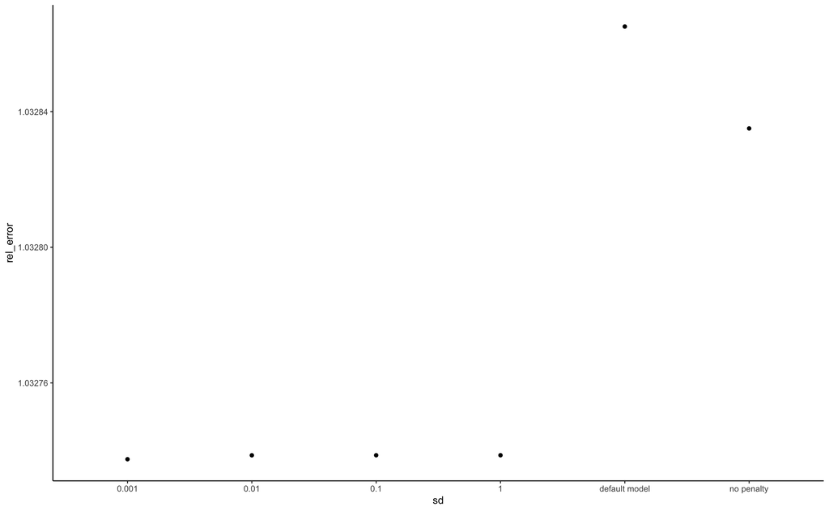

```r
# Calculate mean squared error
mse_mnp_train <- mean(res_mnp_train^2)
mse_mnp_withheld <- mean(res_mnp_withheld^2)

mse_m1_train <- mean(res_m1_train^2)
mse_m1_withheld <- mean(res_m1_withheld^2)

mse_m01_train <- mean(res_m01_train^2)
mse_m01_withheld <- mean(res_m01_withheld^2)

mse_m001_train <- mean(res_m001_train^2)
mse_m001_withheld <- mean(res_m001_withheld^2)

mse_m0001_train <- mean(res_m0001_train^2)
mse_m0001_withheld <- mean(res_m0001_withheld^2)

mse_mdef2_train <- mean(res_mdef2_train^2)
mse_mdef2_withheld <- mean(res_mdef2_withheld^2)

# Compare the relative error on the withheld data to the full data for the full model and the model with oxygen
# Do this by plotting the relative error (withheld/train) as a function of sd

error_df <- data.frame(sd = c("1", "0.1", "0.01", "0.001", "default model", "no penalty"),
                       rel_error = c(mse_mnp_withheld / mse_mnp_train,
                                     mse_m1_withheld / mse_m1_train,
                                     mse_m01_withheld / mse_m01_train,
                                     mse_m001_withheld / mse_m001_train,
                                     mse_m0001_withheld / mse_m0001_train,
                                     mse_mdef2_withheld / mse_mdef2_train))

ggplot(error_df, aes(sd, rel_error)) +
  geom_point()
```